# Lab 5 Assignment

Dhananjay

2023-03-20

## Q1. Get the 2011 Energy Rates dataset

- You will find the data set here: http://cs.ucf.edu/~wiegand/idc6700/datasets/iouzipcodes2011.csv
- The first two lines are comments, starting with the ‘#’ character
- The file has a header and the is comma separated

```r
# Loading the required libraries
library(tidyverse)
# Reading the dataset
zipCodesData <- read.csv("iouzipcodes2011.csv", header = TRUE, sep = ',', skip = 2)
head(zipCodesData)
```

```
##     zip eiaid     utility_name state service_type      ownership comm_rate
## 1 35218   195 Alabama Power Co    AL      Bundled Investor Owned 0.1057612
## 2 35219   195 Alabama Power Co    AL      Bundled Investor Owned 0.1057612
## 3 35214   195 Alabama Power Co    AL      Bundled Investor Owned 0.1057612
## 4 35215   195 Alabama Power Co    AL      Bundled Investor Owned 0.1057612
## 5 35216   195 Alabama Power Co    AL      Bundled Investor Owned 0.1057612
## 6 35210   195 Alabama Power Co    AL      Bundled Investor Owned 0.1057612
##     ind_rate  res_rate
## 1 0.06029244 0.1149433
## 2 0.06029244 0.1149433
## 3 0.06029244 0.1149433
## 4 0.06029244 0.1149433
## 5 0.06029244 0.1149433
## 6 0.06029244 0.1149433
```

```r
summary(zipCodesData)
```

```
##       zip            eiaid       utility_name          state
##  Min.   : 1001   Min.   :  195   Length:37791       Length:37791
##  1st Qu.:15526   1st Qu.: 5109   Class :character   Class :character
##  Median :33702   Median :13573   Mode  :character   Mode  :character
##  Mean   :41699   Mean   :12205
##  3rd Qu.:63144   3rd Qu.:15270
##  Max.   :99950   Max.   :55937
##  service_type        ownership           comm_rate          ind_rate
##  Length:37791       Length:37791       Min.   :0.00000   Min.   :0.00000
##  Class :character   Class :character   1st Qu.:0.05558   1st Qu.:0.03656
##  Mode  :character   Mode  :character   Median :0.08187   Median :0.05981
##                                        Mean   :0.08403   Mean   :0.06316
##                                        3rd Qu.:0.10871   3rd Qu.:0.07890
##                                        Max.   :0.83978   Max.   :0.66864
##     res_rate
##  Min.   :0.00000
##  1st Qu.:0.08025
##  Median :0.10370
##  Mean   :0.10337
##  3rd Qu.:0.13436
##  Max.   :0.84987
```

## Q2. Filter and summarize this dataset

- Produce a new dataset with the five energy companies from Florida
- Summarize the average residential, commercial, and industry rates for each of these over all relevant zip codes
- By way of hints, I used the following functions: filter(), group_by(), summarize(),and melt()

```r
# Loading the required libraries
library(tidyverse)

# Reading the dataset
zipCodesData <- read.csv("iouzipcodes2011.csv", header = TRUE, sep = ',', skip = 2)

# Producing a new dataset with five energy companies from Florida
floridaEnergyCompaniesDataset <- zipCodesData[zipCodesData$state == "FL", ]

# print(floridaEnergyCompaniesDataset)

# summarizing the residential rates by utility_name
summaryResidentialRate <- aggregate(res_rate ~ utility_name, data = floridaEnergyCompaniesDataset, FUN = mean)

# Summarizing the commercial rates by utility_name
summaryCommercialRate <- aggregate(comm_rate ~ utility_name, data = floridaEnergyCompaniesDataset, FUN = mean)

# Summarizing the industrial rates by utility_name
summaryIndustrialRate <- aggregate(ind_rate ~ utility_name, data = floridaEnergyCompaniesDataset, FUN = mean)

# Displaying the resulting summaries
summaryResidentialRate
```

```
##                  utility_name  res_rate
## 1    Florida Power & Light Co 0.1064224
## 2 Florida Public Utilities Co 0.1444489
## 3               Gulf Power Co 0.1201470
## 4 Progress Energy Florida Inc 0.1280416
## 5           Tampa Electric Co 0.1141028
```

```r
summaryCommercialRate
```

```
##                  utility_name  comm_rate
## 1    Florida Power & Light Co 0.09160890
## 2 Florida Public Utilities Co 0.12837461
## 3               Gulf Power Co 0.10484857
## 4 Progress Energy Florida Inc 0.09871816
## 5           Tampa Electric Co 0.10176510
```

```r
summaryIndustrialRate
```

```
##                  utility_name   ind_rate
## 1    Florida Power & Light Co 0.07393682
## 2 Florida Public Utilities Co 0.14138063
## 3               Gulf Power Co 0.08804584
## 4 Progress Energy Florida Inc 0.08774184
## 5           Tampa Electric Co 0.08940169
```

## Q3. Produce a trellis bar plot

- Three panels, one for residential, one for commercial, and one for industry
- All five companies represented in each panel
- Make sure all plot labels are clear and visible

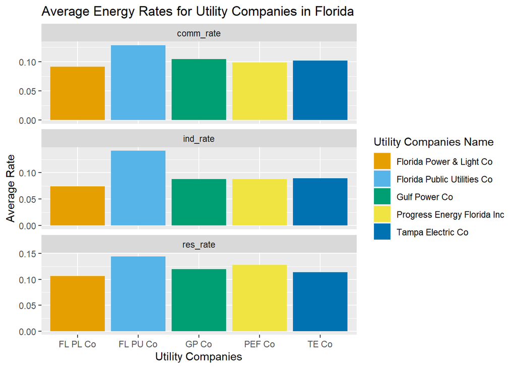

```r
# load the necessary packages
library(tidyverse)
library(ggplot2)
library(dplyr)
library(tidyr)

# Reading the dataset
zipCodesData <- read.csv("iouzipcodes2011.csv", header = TRUE, sep = ',', skip = 2)

# Producing a new dataset with five energy companies from Florida
floridaEnergyCompaniesDataset <- zipCodesData[zipCodesData$state == "FL", ]

# Calculating the average rates by utility_name and rate type
summarized_data <- floridaEnergyCompaniesDataset %>%
  group_by(utility_name) %>%
  summarize(
    res_rate = mean(res_rate),
    comm_rate = mean(comm_rate),
    ind_rate = mean(ind_rate)
  ) %>%
  pivot_longer(cols = c("res_rate", "comm_rate", "ind_rate"),
               names_to = "rate_type",
               values_to = "avg_rate")

# Defining the color encoding
colorCode <- c("#E69F00", "#56B4E9", "#009E73", "#F0E442", "#0072B2")

# Creating the trellis bar plot
ggplot(summarized_data, aes(x = utility_name, y = avg_rate, fill = utility_name)) +
  geom_bar(stat = "identity", position = "dodge") +
  facet_wrap(~rate_type, ncol = 1, scales = "free_y") +
  scale_fill_manual(values = colorCode) +
  labs(title = "Average Energy Rates for Utility Companies in Florida",
       x = "Utility Companies",
       y = "Average Rate",
       fill = "Utility Companies Name") +
  theme(legend.position = "right",
        legend.direction = "vertical",
        legend.box = "vertical") +
  scale_x_discrete(labels = c("FL PL Co", "FL PU Co", "GP Co", "PEF Co", "TE Co"))
```

Consider the following demographics dataset for different countries in 2019 for all three questions: http://cs.ucf.edu/~wiegand/idc6700/datasets/CountryDemographics2019.csv

## Q4. Produce a HeatMap

- Produce a heatmap of this, where the different measure labels (e.g., Total Population, Birth Rate, etc.) are one axis, the different countries are on another axis, and color represents the numeric value. Be sure to scale the values in each measure properly so that one value doesn’t overwhelm the others. Order the measures along the axis representing measures according to total population, so the largest country is on top.

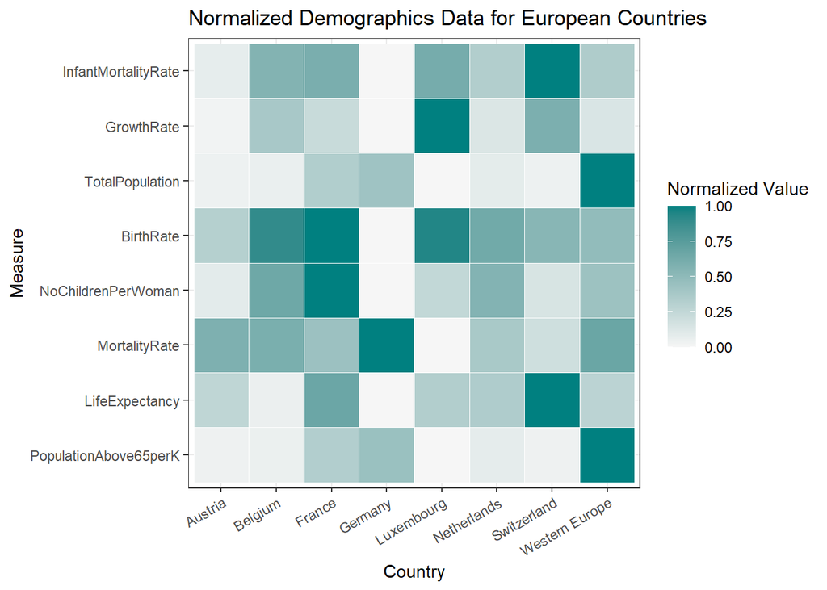

```r
# load the necessary packages
library(tidyverse)
library(ggplot2)
library(reshape2)
# Reading the dataset
countryDemograhicsData <- read.csv("CountryDemographics2019.csv", header = TRUE, sep = ',')

# Sorting the data frame columns by TotalPopulation
countryDemograhicsData <- countryDemograhicsData[, c(1, order(-countryDemograhicsData$TotalPopulation)+1)]

# Defining a function for Min-Max Normalization
minMAxNorm <- function(x) {
  return((x - min(x)) / (max(x) - min(x)))
}

# Applying Min-Max normalization to scale the values in each measure of the data frame
normalizedDemograhicsData <- as.data.frame(lapply(countryDemograhicsData[,2:9], minMAxNorm))
normalizedDemograhicsData <- cbind(Country = countryDemograhicsData$Country, normalizedDemograhicsData)

# Melting the normalized data frame into a "long" format suitable for plotting
meltedDemograhicsData <- melt(normalizedDemograhicsData, id.vars = "Country")

# Setting the plot theme
theme_set(theme_bw())

# Creating the heatmap plot
heatmap_plot <- ggplot(meltedDemograhicsData, aes(Country, variable, fill = value)) +
  geom_tile(color = "white") +
  scale_fill_gradient(low = "#f6f6f6", high = "#008080") +
  labs(title = "Normalized Demographics Data for European Countries",
       x = "Country",
       y = "Measure",
       fill = "Normalized Value") +
  theme(axis.text.x = element_text(angle = 30, hjust = 1))

# Displaying the heatmap plot
print(heatmap_plot)
```

## Q5. Principal Component Analysis

- Consider only the four rate measures (Birth, Mortality, Life, Infant Mortality). Perform and plot a principal component analysis of these numeric data. How many dimensions are needed to explain the overwhelming majority of variance in the data? What do you think is driving this variance, predominantly and why?

```r
# load the necessary packages
library(tidyverse)
library(ggplot2)
library(reshape2)
library(plotrix)

# Reading the dataset
countryDemograhicsData <- read.csv("CountryDemographics2019.csv", header = TRUE, sep = ',')

# Selecting the four rate measures
measureRates <- countryDemograhicsData[, c("BirthRate", "MortalityRate", "LifeExpectancy", "InfantMortalityRate")]
#print(measureRates)

# Scaling the data so that each variable has equal weight in PCA
scaledMeasureRates <- scale(measureRates)
#print(scaledMeasureRates)

# Performing the PCA
measureRatesPCA <- prcomp(scaledMeasureRates)
#print(measureRatesPCA)
summary(measureRatesPCA)
```

```
## Importance of components:
##                          PC1    PC2    PC3     PC4
## Standard deviation     1.697 0.8523 0.5161 0.35688
## Proportion of Variance 0.720 0.1816 0.0666 0.03184
## Cumulative Proportion  0.720 0.9016 0.9682 1.00000
```

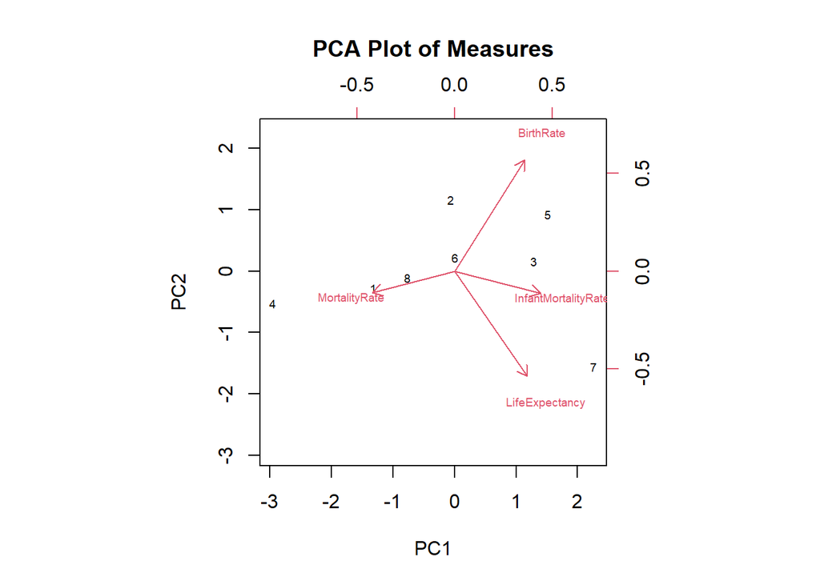

```r
# Plotting the PCA with biplot
biplot(measureRatesPCA, scale = 0, cex = 0.6, main = "")
title("PCA Plot of Measures")
```

The result generated shows that PC1 explains 72% of the variance in the data, while PC2 explains 18.16%. PC3 and PC4 explain only 6.66% and 3.18% of the variance, respectively.

```r
# load the necessary packages
library(tidyverse)
library(ggplot2)
library(reshape2)
library(plotrix)

# Reading the dataset
countryDemograhicsData <- read.csv("CountryDemographics2019.csv", header = TRUE, sep = ',')

# Selecting the four rate measures
measureRates <- countryDemograhicsData[, c("BirthRate", "MortalityRate", "LifeExpectancy", "InfantMortalityRate")]
#print(measureRates)

# Scaling the data so that each variable has equal weight in PCA
scaledMeasureRates <- scale(measureRates)
#print(scaledMeasureRates)

# Performing the PCA
measureRatesPCA <- prcomp(scaledMeasureRates)
#print(measureRatesPCA)
summary(measureRatesPCA)
```

```
## Importance of components:
##                          PC1    PC2    PC3     PC4
## Standard deviation     1.697 0.8523 0.5161 0.35688
## Proportion of Variance 0.720 0.1816 0.0666 0.03184
## Cumulative Proportion  0.720 0.9016 0.9682 1.00000
```

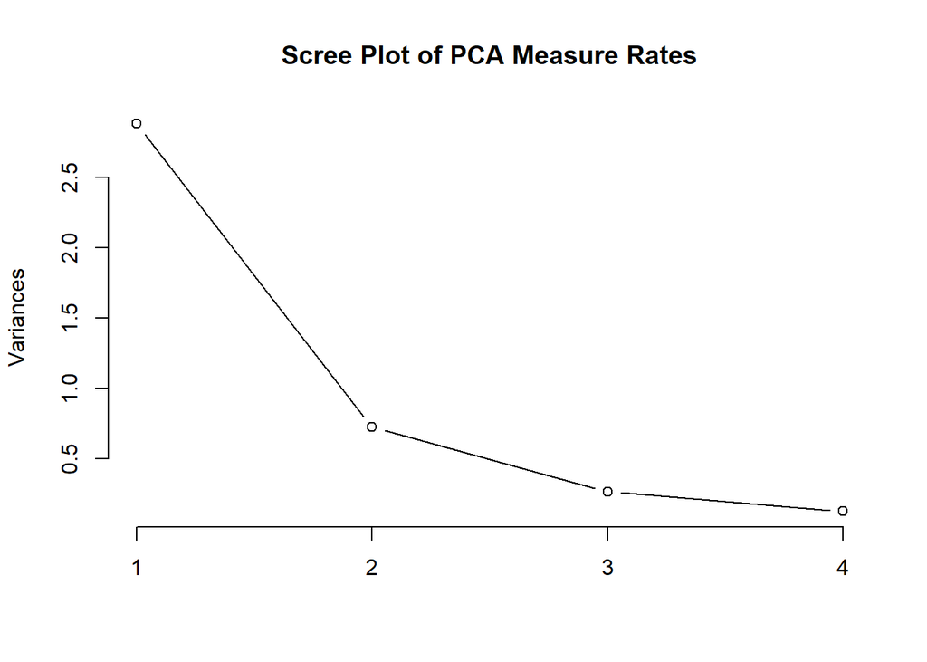

```r
# Generating the scree plot to explain the majority of variance in the data
plot(measureRatesPCA, type = "lines", main = "")
title("Scree Plot of PCA Measure Rates")
```

## Q6. Clustering

- Perform hierarchical clustering on the data set. Plot the dendogram. Notice that one cluster is on a leaf by itself. Which item in the dataset is this? Why do you think it is so separated from the others?

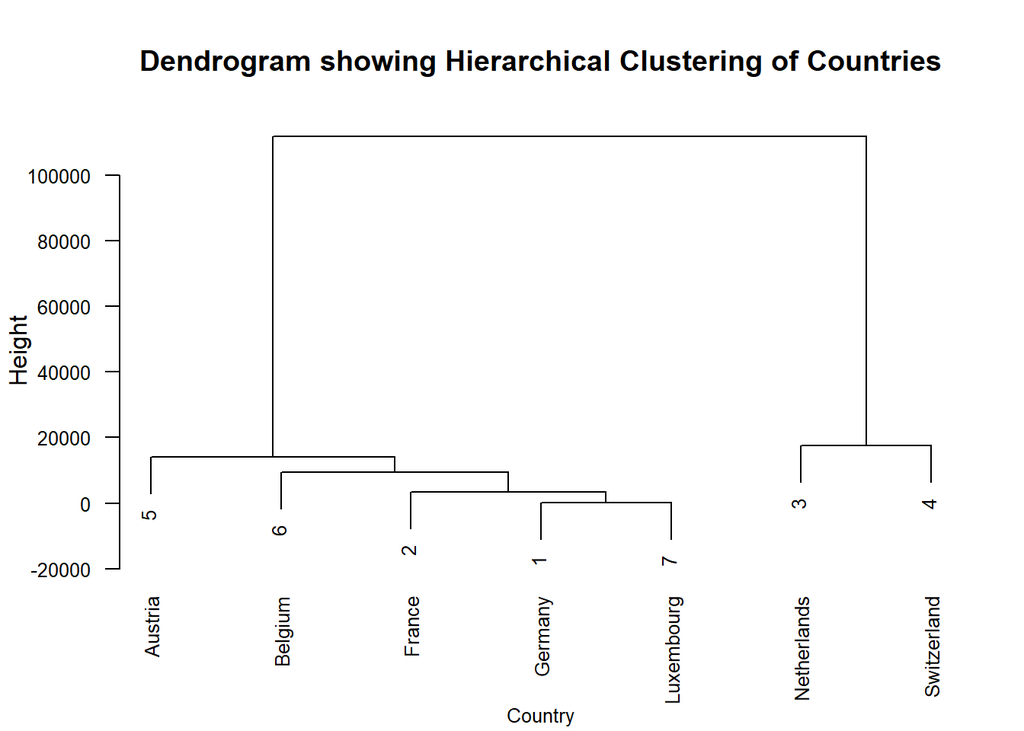

```r
# load the necessary packages
library(tidyverse)
library(ggplot2)
library(reshape2)
library(plotrix)

# Reading the dataset
countryDemograhicsData <- read.csv("CountryDemographics2019.csv", header = TRUE, sep = ',')

# Removing WesternEurope from the data frame
countryDemograhicsData <- countryDemograhicsData[-8,]

# Removing the Country column (not needed for clustering)
clustCountryDemograhicsData <- countryDemograhicsData[, -1]

# Set larger plot size
options(repr.plot.width = 8, repr.plot.height = 6)

# Perform hierarchical clustering using the ward.D2 linkage method
hierarchialClusteredCountryDemograhicsData <- hclust(dist(clustCountryDemograhicsData), method = "ward.D2")

# Plot the dendrogram with smaller label font size, empty main title, and rotated y-axis labels
plot(hierarchialClusteredCountryDemograhicsData, cex = 0.8, main = "", xaxt = "n", yaxt = "n", xlab = "", sub = "")
axis(side = 2, cex.axis = 0.8, las = 1)

# Add a title and axis labels
title("Dendrogram showing Hierarchical Clustering of Countries")
xlabel <- "Country"
axis(side = 1, at = 1:length(countryDemograhicsData$Country), labels = countryDemograhicsData$Country, tick = FALSE, las = 2, line = -0.5, cex.axis = 0.8)
mtext(xlabel, side = 1, line = 4, cex = 0.8)
```

## Q7. How certain are you which Start Wars character is the best? Consider the StarWars.csv (from FiveThirtyEight) dataset.

- Read the file into R
- Determine which partipants watched all 6 Star War movies.
- From those repondants who watched all 6 movies - produce a visualization ranking the 6 movies (which expresses how certain you are of this ranking).
- Produce a visualization that conveys the ranking of the characters in Star Wars, again expressing how certain you are of this ranking.

```r
# load the necessary packages
library(tidyverse)
library(ggplot2)
library(reshape2)
library(plotrix)

# Reading the dataset
starWarsData <- read.table("StarWars.csv", header = TRUE, sep = ',')
head(starWarsData)
```

[output not shown]

[output cut: 106 more lines]

```
## 6                                                               No     Male
##        Age  Household.Income                        Education
## 1 Response          Response                         Response
## 2    18-29      $0 - $24,999               High school degree
## 3    18-29 $25,000 - $49,999 Some college or Associate degree
## 4
## 5
## 6    18-29 $25,000 - $49,999                  Bachelor degree
##   Location..Census.Region.
## 1                 Response
## 2       West North Central
## 3                  Pacific
## 4
## 5
## 6           South Atlantic
```

```r
#names(starWarsData)
```